# From Coal to Renewables: Analysis of Global Energy Consumption

Michael Malis, Markiel Kaykov

## Background

Global energy supply sits at the heart of every modern economy, yet the pace and direction of the world’s transition away from fossil fuels remains uneven and poorly understood.

To obtain a high-resolution view of these dynamics we draw on the open [**Our World in Data – Global Energy**](https://github.com/owid/energy-data/tree/master) dataset, which reports annual production and consumption figures—broken down by source—for more than two hundred countries.

We enrich the core file with auxiliary information from the [**World Bank Country and Lending Groups**](https://datahelpdesk.worldbank.org/knowledgebase/articles/906519-world-bank-country-and-lending-groups) classification, allowing us to tag each observation by income level.

Using this combined resource we

- reconstruct the long-run trajectories of oil, coal, gas and low-carbon sources, contrasting absolute growth with shifts in the global energy mix;
- compare distributions of fossil, nuclear and renewable shares across all countries in 1982, 2002 and 2022 through empirical CDFs;
- locate and interpret the sharpest single-year collapses in nuclear generation (e.g., Japan post-Fukushima);
- visualise geographic patterns—nuclear reliance, per-capita demand, gas consumption—via choropleth world maps;
- quantify how energy use scales with national income by means of box-plots and outlier analysis;

## Libraries used in this project

- **tidyverse** – main toolkit for data wrangling (`dplyr`, `%>%`) and plotting (`ggplot2`)
- **data.table** – fast filtering, joins and aggregations on large tables
- **rworldmap** – ready-made world-map shapes for quick choropleths
- **ggthemes** – extra themes to give plots a clean, publication-style look
- **reshape2** – classic `melt()` / `dcast()` helpers for reshaping wide ↔︎ long
- **e1071** – handy statistical utilities (e.g., skewness, kurtosis)
- **readxl** – reading the World Bank Excel sheet with income groups

*General note*: the some values throughout the entire work are presented in scientific notation. For example:

3e+04 means 3 × 10⁴, 7e+07 means 7 × 10⁷.

### Part 1: Loading and preparing the data

#### 1.1 Importing and inspecting the dataset

We read the full `owid-energy-data.csv` file, let R infer each column’s class, and confirm that the essentials are in place: years are integers, country names are character strings, and nearly every energy metric arrives as numeric. A glance at the top five rows shows 21 812 observations spanning thirtenn decades and 130 separate variables. Regional aggregates such as “ASEAN (Ember)” lack population and GDP, yet they still carry the energy figures we will analyse, so we leave them in.

```r
#Load dataset
energyData = read.csv("D:\\_HUJI\\owid-energy-data.csv")

# Check column types and show first 5 rows
str(energyData, vec.len = 1)
```

```
## 'data.frame':    21812 obs. of  130 variables:
##  $ country                                     : chr  "ASEAN (Ember)" ...
##  $ year                                        : int  2000 2001 ...
##  $ iso_code                                    : chr  "" ...
##  $ population                                  : num  NA NA ...
##  $ gdp                                         : num  NA NA ...
##  $ biofuel_cons_change_pct                     : num  NA NA ...
##  $ biofuel_cons_change_twh                     : num  NA NA ...
##  $ biofuel_cons_per_capita                     : num  NA NA ...
##  $ biofuel_consumption                         : num  NA NA ...
##  $ biofuel_elec_per_capita                     : num  NA NA ...
##  $ biofuel_electricity                         : num  5.87 6.46 ...
##  $ biofuel_share_elec                          : num  1.55 ...
##  $ biofuel_share_energy                        : num  NA NA ...
##  $ carbon_intensity_elec                       : num  570 ...
```

[output cut: 86 more lines]

```r
head(energyData, 5)
```

|  | country | year | iso_code | population | gdp | biofuel_cons_change_pct | biofuel_cons_change_twh | biofuel_cons_per_capita | biofuel_consumption | biofuel_elec_per_capita | biofuel_electricity | biofuel_share_elec | biofuel_share_energy | carbon_intensity_elec | coal_cons_change_pct | coal_cons_change_twh | coal_cons_per_capita | coal_consumption | coal_elec_per_capita | coal_electricity | coal_prod_change_pct | coal_prod_change_twh | coal_prod_per_capita | coal_production | coal_share_elec | coal_share_energy | electricity_demand | electricity_demand_per_capita | electricity_generation | … |
| --- | --- | --- | --- | --- | --- | --- | --- | --- | --- | --- | --- | --- | --- | --- | --- | --- | --- | --- | --- | --- | --- | --- | --- | --- | --- | --- | --- | --- | --- | --- |
| 1 | ASEAN (Ember) | 2000 |  | NA | NA | NA | NA | NA | NA | NA | 5.87 | 1.550 | NA | 569.557 | NA | NA | NA | NA | NA | 76.03 | NA | NA | NA | NA | 20.081 | NA | 378.61 | NA | 378.61 | … |
| 2 | ASEAN (Ember) | 2001 |  | NA | NA | NA | NA | NA | NA | NA | 6.46 | 1.596 | NA | 567.642 | NA | NA | NA | NA | NA | 86.26 | NA | NA | NA | NA | 21.307 | NA | 404.85 | NA | 404.85 | … |
| 3 | ASEAN (Ember) | 2002 |  | NA | NA | NA | NA | NA | NA | NA | 6.62 | 1.528 | NA | 570.212 | NA | NA | NA | NA | NA | 93.43 | NA | NA | NA | NA | 21.568 | NA | 433.19 | NA | 433.19 | … |
| 4 | ASEAN (Ember) | 2003 |  | NA | NA | NA | NA | NA | NA | NA | 7.45 | 1.626 | NA | 574.699 | NA | NA | NA | NA | NA | 102.01 | NA | NA | NA | NA | 22.261 | NA | 458.24 | NA | 458.24 | … |
| 5 | ASEAN (Ember) | 2004 |  | NA | NA | NA | NA | NA | NA | NA | 8.40 | 1.692 | NA | 581.420 | NA | NA | NA | NA | NA | 115.01 | NA | NA | NA | NA | 23.161 | NA | 496.56 | NA | 496.56 | … |

Viewing the first five rows confirms that our data loaded as expected and is ready for analysis.

#### 1.2 A first country-level check

To ground the numbers in something concrete, we want to examine how Israel’s natural-gas consumption has evolved in recent years, and list its five latest values for `gas_consumption` (TWh). We will filter the dataset for “Israel,” sort by year (newest first), drop any missing values, and then display the most recent five observations of gas_consumption in TWh.

```r
# b. Israel's gas consumption over the last 5 years
israel_gas <- energyData %>%
  filter(country == "Israel") %>%
  arrange(desc(year)) %>%
  select(year, gas_consumption) %>%
  filter(!is.na(gas_consumption)) %>%
  head(5)

print(israel_gas)
```

```
##   year gas_consumption
## 1 2023         125.673
## 2 2022         121.423
## 3 2021         117.337
## 4 2020         112.682
## 5 2019         107.219
```

Israel’s gas consumption has risen steadily from about 107 TWh in 2019 to nearly 126 TWh in 2023. This consistent upward trend reflects the country’s growing reliance on natural gas as part of its energy mix. The data suggest that new gas fields and infrastructure investments are driving higher annual usage.

#### 1.3 Reshaping for cross-fuel comparison

Finally, we tidy three headline variables—`gas_consumption`, `coal_consumption`, and `hydro_consumption`—by pivoting them from wide to long form. The resulting frame keeps a lean four-column structure (`country`, `year`, `Source`, `Source_cons`) that is easier to group, plot and summarise. We use reshape2::melt() to pivot those three variables into a long format, then filter out NA and zero values, and finally select the five smallest positive consumption records.

```r
# c. Convert to long format using melt
longEnergy <- melt(
  energyData,
  id.vars = c("country", "year"),
  measure.vars = c("gas_consumption", "coal_consumption", "hydro_consumption"),
  variable.name = "Source",
  value.name = "Source_cons"
)

# Filter out NA and zero values, show 5 rows with the smallest non-zero consumption
clean_sorted_energy <- longEnergy %>%
  filter(!is.na(Source_cons), Source_cons > 0) %>%
  arrange(Source_cons)

head(clean_sorted_energy, 5)
```

|  | country | year | Source | Source_cons |
| --- | --- | --- | --- | --- |
| 1 | Eastern Africa (EI) | 1987 | gas_consumption | 0.001 |
| 2 | Eastern Africa (EI) | 1989 | gas_consumption | 0.001 |
| 3 | Eastern Africa (EI) | 1991 | gas_consumption | 0.001 |
| 4 | Azerbaijan | 2022 | coal_consumption | 0.001 |
| 5 | Azerbaijan | 2023 | coal_consumption | 0.001 |

The table lists the five (country, year, source) combinations with the smallest non-zero consumption values for gas, coal, and hydro. Eastern Africa (EI) appears three times with just 0.001 TWh of gas in 1987, 1989, and 1991, and Azerbaijan shows 0.001 TWh of coal in 2022–23. These near-zero figures reflect either very low actual usage or rounding in the underlying data, and they illustrate the lower bound of reported energy consumption across regions and sources.

### Part 2: How the world’s fuel mix has evolved

#### 2.1 Absolute trajectories, 1965 – 2023

To put every major fuel on the same time axis we isolate the **World** aggregate, discard four composite totals, and reshape the remaining `_consumption` columns into a tidy long table.

Ordering the legend by each fuel’s 2023 size keeps the biggest player, **oil**, at the bottom and the smallest, **renewables**, at the top.

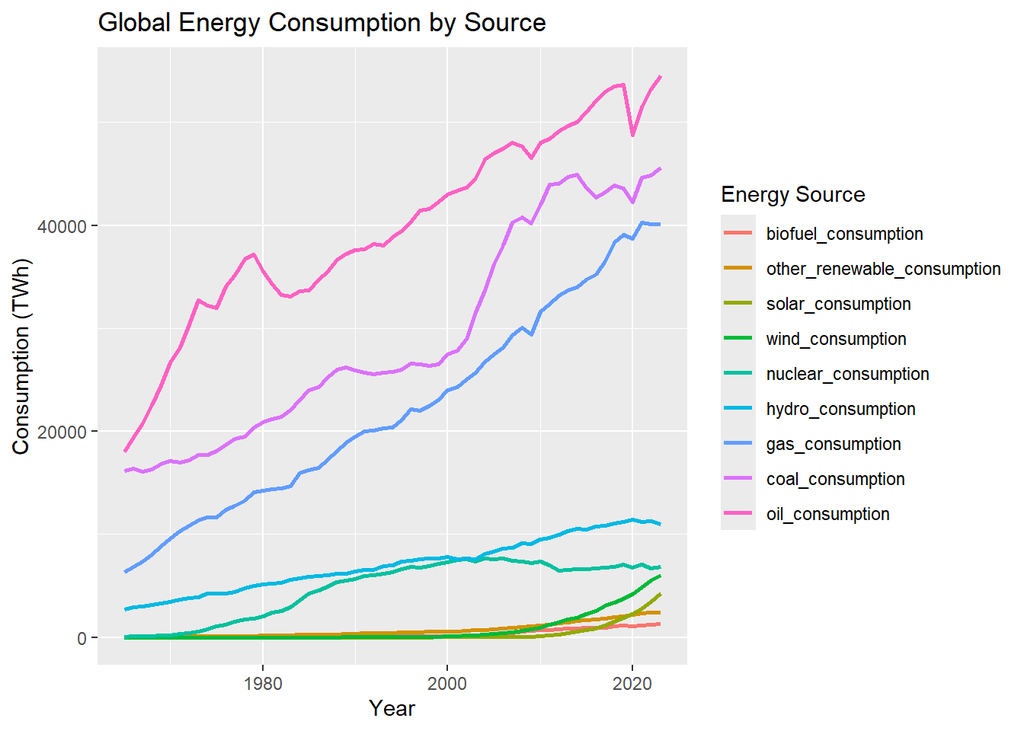

```r
worldEnergy <- energyData %>%
  filter(country == "World")

excluded <- c("primary_energy_consumption",
              "renewables_consumption",
              "low_carbon_consumption",
              "fossil_fuel_consumption")

sources <- worldEnergy %>%
  select(
    year,                       #keep the year column
    ends_with("_consumption"),  #every column ending with "_consumption"
    -all_of(excluded)           #drop excluded columns
  )


#Helper function + drop empty years

notNA <- function(x) {          #TRUE when value is not NA
  !is.na(x)
}

sources <- sources %>%
  filter(
    if_any(-year, notNA)        #keep years where at least one source is not NA
)

longEnergy <- melt(
  sources,
  id.vars       = "year",
  variable.name = "source",
  value.name    = "consumption") %>%
  #melt() keeps NA rows for each (year, source) pair.
  #We drop them so blank points don’t clutter the plot
  #and percentage calculations aren’t polluted by NA values.
  filter(!is.na(consumption))

order2023 <- longEnergy %>%
  filter(year == 2023) %>%     #keep only rows for 2023
  arrange(consumption) %>%     #smallest → largest
  pull(source)                 #pull order vector from data frame

ggplot(longEnergy,
       aes(year, consumption,
           colour = factor(source, levels = order2023))) +
  geom_line(linewidth = 1) +
  labs(title  = "Global Energy Consumption by Source",
       x      = "Year",
       y      = "Consumption (TWh)",
       colour = "Energy Source")
```

The line chart displays global energy consumption from the 1960s through 2023 for individual sources: oil, coal, gas, hydro, nuclear, wind, solar, other renewables, and biofuel, each colored and ordered so the largest 2023 source, oil, sits at the bottom of the legend. Oil and coal have long dominated world energy use, rising steadily until a slight dip in 2020, while natural gas follows a similar but somewhat smoother upward path. Nuclear and hydro grew through the 1970–90s before leveling off, and modern renewables (wind, solar, biofuel, other) only begin to climb appreciably after 2000. This reflects the ongoing, yet still modest, shift toward low-carbon sources amid continued reliance on fossil fuels.

#### 2.2 Shifting shares, 1975 – present

From the same long table we compute each fuel’s share of world consumption, year by year, starting in 1975 and visualize how those shares have shifted over time.

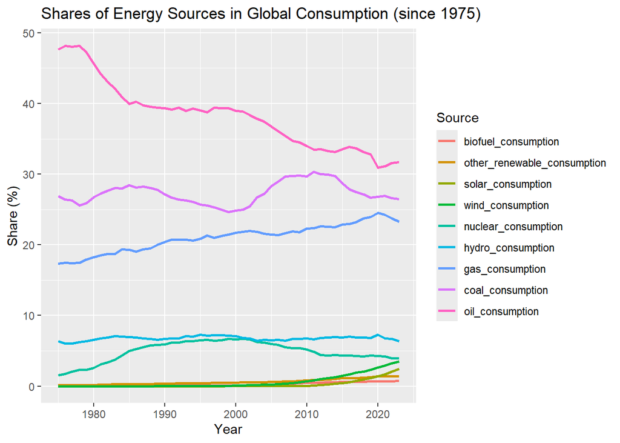

```r
shares <- longEnergy %>%
  filter(year >= 1975) %>%
  group_by(year) %>%
  mutate(
    total = sum(consumption),
    share = 100 * consumption / total
  )

ggplot(shares,
       aes(year, share,
           colour = factor(source, levels = order2023))) +
  geom_line(linewidth = 1) +
  labs(title  = "Shares of Energy Sources in Global Consumption (since 1975)",
       x      = "Year",
       y      = "Share (%)",
       colour = "Source")
```

### Part 3: Energy use per person and income

#### 3.1 Extremes in per-capita electricity and their growth paths

We start by picking out the three countries with the highest and the three with the lowest values of **per-capita electricity use** in 2023 (excluding regional aggregates and missing data) and then track their **energy per capita** back to 1980, and also we compare them to the world average.

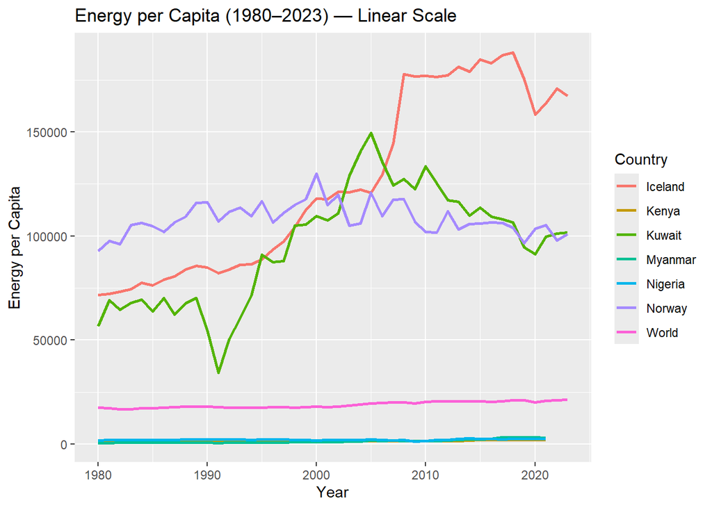

```r
#Identify top-3 and bottom-3 countries by per_capita_electricity in 2023
countries_2023 <- energyData %>%
  filter(
    year == 2023,
    !is.na(per_capita_electricity),
    per_capita_electricity > 0,
    country != "World",               # exclude the global aggregate
    !str_detect(country, "\\(")       # exclude entries like "Africa (EI)"
  )

top3  <- countries_2023 %>%
  arrange(desc(per_capita_electricity)) %>%
  slice_head(n = 3) %>%
  pull(country)

bot3  <- countries_2023 %>%
  arrange(per_capita_electricity) %>%
  slice_head(n = 3) %>%
  pull(country)

sel_countries <- c(top3, bot3, "World")

# Prepare time series for these countries since 1980
ts_data <- energyData %>%
  filter(
    country %in% sel_countries,
    year >= 1980,
    !is.na(energy_per_capita)
  ) %>%
  select(country, year, energy_per_capita)

# Plot on a linear scale
p1 <- ggplot(ts_data, aes(x = year, y = energy_per_capita, color = country)) +
  geom_line(size = 1) +
  labs(
    title = "Energy per Capita (1980–2023) — Linear Scale",
    x     = "Year",
    y     = "Energy per Capita",
    color = "Country"
  )
# Plot on a logarithmic scale
p2 <- ggplot(ts_data, aes(x = year, y = energy_per_capita, color = country)) +
  geom_line(size = 1) +
  scale_y_log10() +
  labs(
    title = "Energy per Capita (1980–2023) — Logarithmic Scale",
    x     = "Year",
    y     = "Energy per Capita (log10)",
    color = "Country"
  )

# Display both plots
print(p1)
```

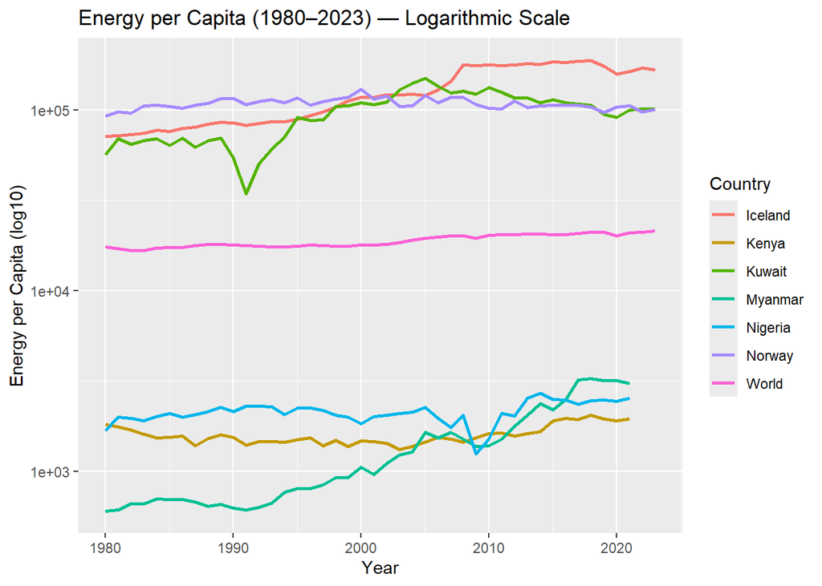

```r
print(p2)
```

#### 3.2 How energy demand varies by income tier

Next we join the World Bank’s income groups to the energy panel and look at **energy per capita in 2021**.  
We want to explore how energy consumption per person varies across different income groups. We use boxplots to compare groups and identify outlier countries with extremely high or low values.

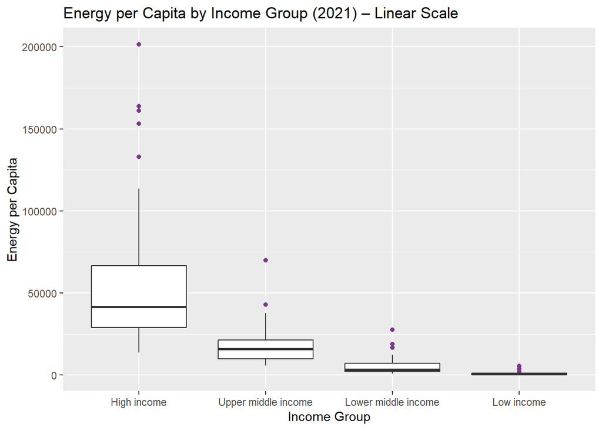

```r
# Load income classification from the first sheet
income <- read_excel(
  "D:\\_HUJI\\CLASS.xlsx",
  sheet = "List of economies",
  skip  = 0) %>%
  select(iso_code = Code, IncomeGroup = `Income group`)

# Merge with energyData by country name
energy_income <- energyData %>%
                 left_join(income, by = "iso_code")

# Filter for year 2021, valid countries, and non-zero per capita energy
plot_df <- energy_income %>%
  filter(
    year == 2021,
    !is.na(energy_per_capita),
    energy_per_capita > 0,
    country != "World",
    !str_detect(country, "\\(EI\\)"),
    !is.na(IncomeGroup)
  ) %>%
  mutate(
    IncomeGroup = factor(IncomeGroup,
                         levels = c("High income",
                                    "Upper middle income",
                                    "Lower middle income",
                                    "Low income"))
  )

# Create boxplot on linear scale
p_linear <- ggplot(plot_df, aes(x = IncomeGroup, y = energy_per_capita)) +
  geom_boxplot(outlier.colour = "mediumorchid4") +
  labs(
    title = "Energy per Capita by Income Group (2021) – Linear Scale",
    x     = "Income Group",
    y     = "Energy per Capita"
  )
# Create boxplot on logarithmic scale
p_log <- ggplot(plot_df, aes(x = IncomeGroup, y = energy_per_capita)) +
  geom_boxplot(outlier.colour = "mediumorchid4") +
  scale_y_log10() +
  labs(
    title = "Energy per Capita by Income Group (2021) – Log Scale",
    x     = "Income Group",
    y     = "Energy per Capita (log scale)"
  )

# Display both plots
print(p_linear)
```

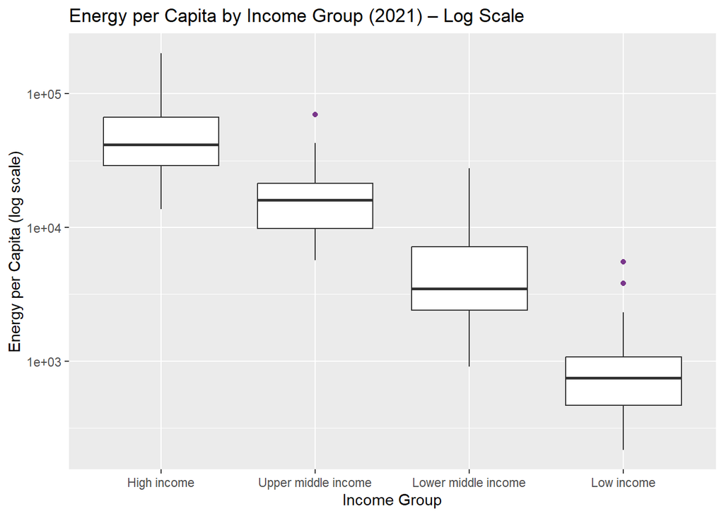

```r
print(p_log)
```

```r
# Linear scale outliers
outliers_linear <- plot_df %>%
  group_by(IncomeGroup) %>%
  mutate(
    Q1 = quantile(energy_per_capita, 0.25),
    Q3 = quantile(energy_per_capita, 0.75),
    IQR = Q3 - Q1
  ) %>%
  ungroup() %>%
  filter(
    energy_per_capita < (Q1 - 1.5 * IQR) |
    energy_per_capita > (Q3 + 1.5 * IQR)
  ) %>%
  select(country, IncomeGroup, energy_per_capita)

# Log scale outliers
outliers_log <- plot_df %>%
  mutate(log_energy = log10(energy_per_capita)) %>%
  group_by(IncomeGroup) %>%
  mutate(
    Q1 = quantile(log_energy, 0.25),
    Q3 = quantile(log_energy, 0.75),
    IQR = Q3 - Q1
  ) %>%
  ungroup() %>%
  filter(
    log_energy < (Q1 - 1.5 * IQR) |
    log_energy > (Q3 + 1.5 * IQR)
  ) %>%
  select(country, IncomeGroup, energy_per_capita)

# Print outlier lists
print(outliers_linear)
```

```
## # A tibble: 15 × 3
##    country              IncomeGroup         energy_per_capita
##    <chr>                <fct>                           <dbl>
##  1 Bahrain              High income                   161111.
##  2 Bhutan               Lower middle income            27785.
##  3 Iceland              High income                   163755.
##  4 Kazakhstan           Upper middle income            42831.
##  5 Laos                 Lower middle income            18847.
##  6 Lebanon              Lower middle income            18832.
##  7 Mozambique           Low income                      2241.
##  8 North Korea          Low income                      3834.
##  9 Qatar                High income                   201563.
## 10 Singapore            High income                   153291.
## 11 Sudan                Low income                      2317.
## 12 Syria                Low income                      5507.
## 13 Turkmenistan         Upper middle income            69869.
## 14 United Arab Emirates High income                   133080.
## 15 Uzbekistan           Lower middle income            16601.
```

```r
print(outliers_log)
```

```
## # A tibble: 3 × 3
##   country      IncomeGroup         energy_per_capita
##   <chr>        <fct>                           <dbl>
## 1 North Korea  Low income                      3834.
## 2 Syria        Low income                      5507.
## 3 Turkmenistan Upper middle income            69869.
```

Switching to a logarithmic axis levels the playing field. The boxes are similar in height, whiskers shrink, and just three nations remain outliers: North Korea and Syria for the low-income class, and Turkmenistan for upper-middle. The log transform mutes the petro-states’ dominance and uncovers subtler deviations.

Taken together, the graphs confirm that richer countries generally consume more energy, yet resource endowment, climate and policy can push nations far above or below the income trend.

#### 3.3 Linking energy use to economic output

Finally, focusing on 2022, we calculate **GDP per capita** and run a simple linear regression against **energy per capita**. Also we create a scatter plot with a regression line to visualize the relationship.

```r
# Prepare 2022 data and compute GDP per capita
reg_df <- energyData %>%
  filter(
    year == 2022,
    country != "World",              # exclude global aggregate
    !str_detect(country, "\\("),     # exclude region aggregates like "(EI)"
    !is.na(gdp),
    !is.na(population),
    !is.na(energy_per_capita)
  ) %>%
  mutate(
    gdp_per_capita = gdp / population
  )

# Fit linear model: energy_per_capita ~ gdp_per_capita
model <- lm(energy_per_capita ~ gdp_per_capita, data = reg_df)

# Display regression summary (intercept, slope, R-squared, p-values)
summary(model)
```

```
##
## Call:
## lm(formula = energy_per_capita ~ gdp_per_capita, data = reg_df)
##
## Residuals:
##    Min     1Q Median     3Q    Max
## -52572 -11853  -3197   5980 113555
##
## Coefficients:
##                 Estimate Std. Error t value Pr(>|t|)
## (Intercept)    -633.3112  4774.6660  -0.133    0.895
## gdp_per_capita    1.3500     0.1232  10.959   <2e-16 ***
## ---
## Signif. codes:  0 '***' 0.001 '**' 0.01 '*' 0.05 '.' 0.1 ' ' 1
##
## Residual standard error: 24190 on 76 degrees of freedom
## Multiple R-squared:  0.6125, Adjusted R-squared:  0.6074
## F-statistic: 120.1 on 1 and 76 DF,  p-value: < 2.2e-16
```

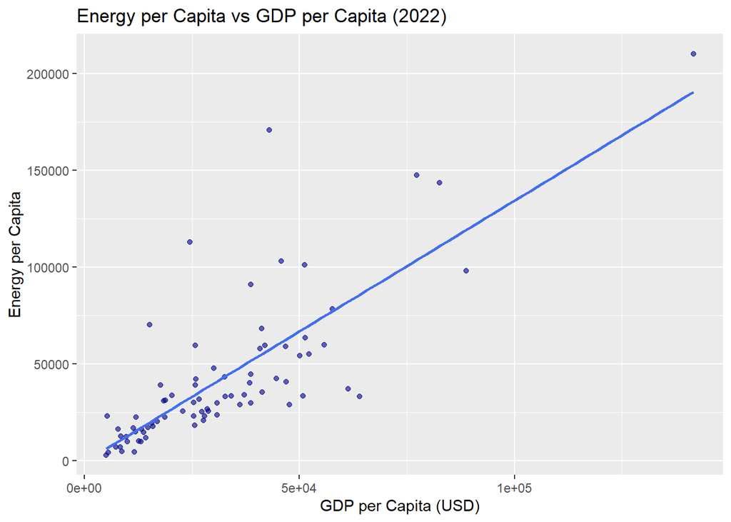

```r
# Scatter plot with fitted regression line
ggplot(reg_df, aes(x = gdp_per_capita, y = energy_per_capita)) +
  geom_point(alpha = 0.6, color = "darkblue") +
  geom_smooth(method = "lm", se = FALSE, color = "royalblue2") +
  labs(
    title = "Energy per Capita vs GDP per Capita (2022)",
    x     = "GDP per Capita (USD)",
    y     = "Energy per Capita"
  )
```

The graph shows energy per person on the y-axis and GDP per person on the x-axis for each country in 2022. Each point is a country, and the blue line shows the fitted linear trend.

The regression line shows a strong positive relationship between GDP per capita and energy per capita. The slope is 1.35, meaning that for every extra $1 of GDP per person, energy use increases by 1.35 units. The intercept is not significant (p = 0.895), so the model doesn’t give meaningful predictions at very low GDP. The R-squared is 0.61, which means about 61% of the variation in energy use can be explained by GDP per person. The p-value for the slope is extremely small (< 2.2e-16), so the result is statistically significant and unlikely to be due to chance.

### Part 4: How the energy mix is distributed and where it is heading

#### 4.1 Global distributions of fossil, nuclear and renewable shares

To see how the world’s fuel split has shifted, we draw empirical CDFs for each major category—fossil, nuclear and renewables—using three benchmark years: 1982, 2002 and 2022.

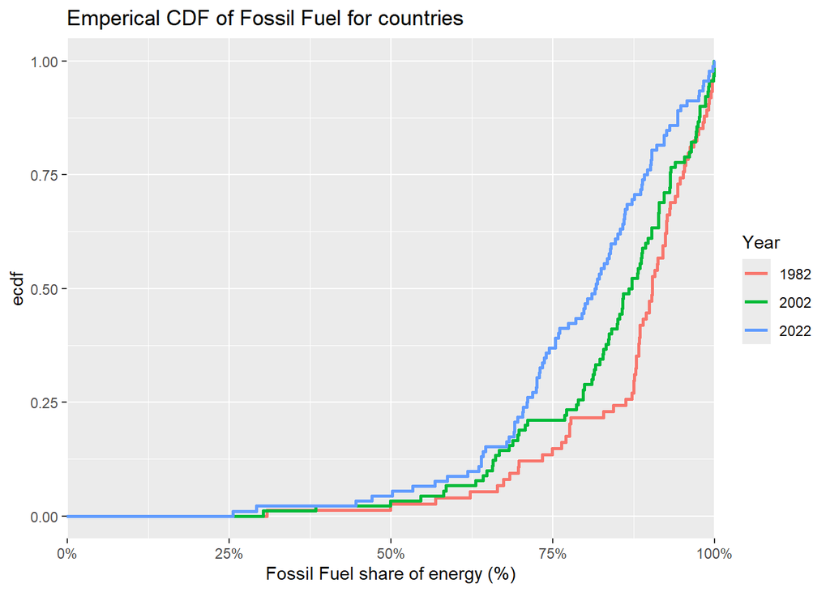

```r
# This function plots the empirical CDF of a specific energy share variable
# for countries for the years 1982, 2002, and 2022.
plot_ecdf_by_years <- function(data, energy_col, energy_label) {
  data %>%
    # Keep only the target years and rows with non-missing values
    filter(year %in% c(1982, 2002, 2022), !is.na(.data[[energy_col]])) %>%

    # Select relevant columns: country, year, and the energy share variable
    select(country, year, value = all_of(energy_col)) %>%

    # Create empirical CDF plot
    ggplot(aes(x = value, color = factor(year))) +
    stat_ecdf(size = 1) +  # Draw empirical CDF lines

    # Format the x-axis as percentages
    scale_x_continuous(
      limits = c(0, NA),
      expand = c(0.001, 0),
      labels = scales::percent_format(scale = 1, accuracy = 1)
    ) +

    # Set plot labels dynamically based on energy type
    labs(
      title = paste("Emperical CDF of", energy_label, "for countries"),
      x     = paste(energy_label, "share of energy (%)"),
      color = "Year"
    )
}

# Fossil fuel share
plot_ecdf_by_years(energyData, "fossil_share_energy", "Fossil Fuel")
```

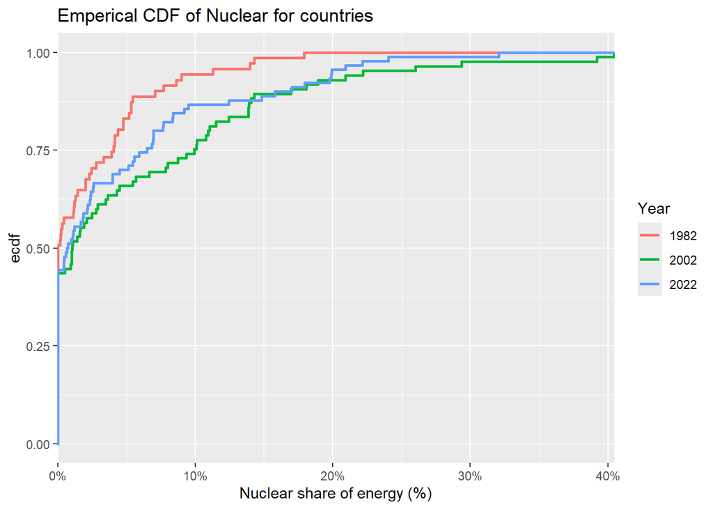

```r
# Nuclear energy share
plot_ecdf_by_years(energyData, "nuclear_share_energy", "Nuclear")
```

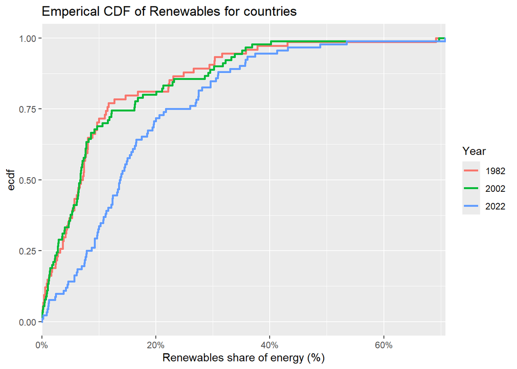

```r
# Renewables energy share
plot_ecdf_by_years(energyData, "renewables_share_energy", "Renewables")
```

#### 4.2 A 2022 snapshot across eight economies

Next we freeze the clock at 2022 and stack fossil, nuclear and renewable shares for a set of large and diverse economies: Brazil, India, the United States, France, China, Australia, Ukraine and the world average. We use a stacked bar chart to visualize how each country’s energy supply is composed. This helps identify which countries rely more on clean energy and which still depend on fossil fuels.

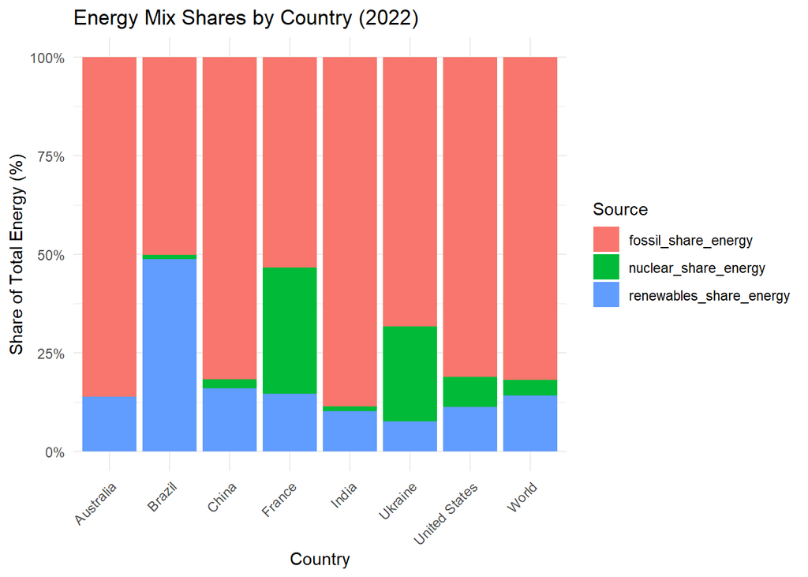

```r
# Define the set of countries
countries <- c(
  "Brazil", "India", "United States", "France",
  "China", "World", "Ukraine", "Australia"
)

# Filter for 2022 and select the three share columns
data2022 <- energyData %>%
  filter(year == 2022, country %in% countries) %>%
  select(
    country,
    fossil_share_energy,
    nuclear_share_energy,
    renewables_share_energy
  )

# Melt into long format
long2022 <- melt(
  data2022,
  id.vars       = "country",
  measure.vars  = c(
    "fossil_share_energy",
    "nuclear_share_energy",
    "renewables_share_energy"
  ),
  variable.name = "source",
  value.name    = "share"
) %>%
  filter(!is.na(share))

# Stacked bar chart of shares by country
ggplot(long2022, aes(x = country, y = share, fill = source)) +
  geom_bar(stat = "identity") +
  scale_y_continuous(labels = scales::percent_format(scale = 1, accuracy = 1)) +
  labs(
    title = "Energy Mix Shares by Country (2022)",
    x     = "Country",
    y     = "Share of Total Energy (%)",
    fill  = "Source"
  ) +
  theme_minimal() +
  theme(
    axis.text.x = element_text(angle = 45, hjust = 1)
  )
```

Each bar represents a country, and its height is divided into three parts showing the share of fossil fuels, nuclear, and renewables.

This comparison highlights big differences in national energy policies and levels of investment in clean energy sources.

#### 4.3 Past and future of the UK mix, benchmarked to the 2030 target

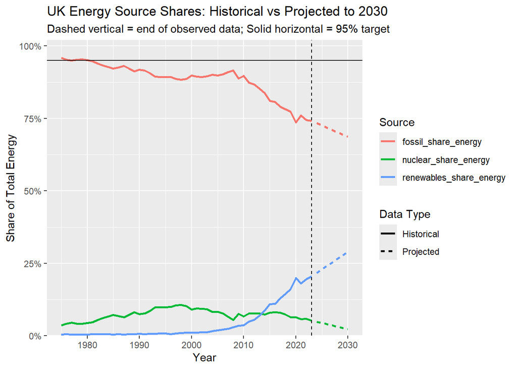

```r
# Historical UK data from 1975
uk_hist <- energyData %>%
  filter(country == "United Kingdom", year >= 1975) %>%
  select(
    year,
    fossil_share_energy,
    nuclear_share_energy,
    renewables_share_energy
  ) %>%
  arrange(year) %>%
  mutate(across(-year, ~ .x / 100))  # Convert percentages to proportions

# Compute average yearly change over the last 5 years
src_cols <- c("fossil_share_energy", "nuclear_share_energy", "renewables_share_energy")

avg_changes <- map_df(src_cols, function(src) {
  vals  <- uk_hist[[src]]
  diffs <- diff(vals)
  tibble(
    source     = src,
    avg_change = mean(tail(diffs, 5), na.rm = TRUE)
  )
})

# Build projection from last observed year through 2030
last_year  <- max(uk_hist$year)
proj_years <- (last_year + 1):2030

last_vals <- uk_hist %>%
  filter(year == last_year) %>%
  select(-year) %>%
  pivot_longer(everything(), names_to = "source", values_to = "last_share")

proj_df <- expand_grid(year = proj_years, source = avg_changes$source) %>%
  left_join(avg_changes, by = "source") %>%
  left_join(last_vals,    by = "source") %>%
  mutate(share = last_share + avg_change * (year - last_year)) %>%
  select(year, source, share)

# Melt historical data
hist_df <- melt(
  uk_hist,
  id.vars       = "year",
  measure.vars  = src_cols,
  variable.name = "source",
  value.name    = "share"
)

# Combine and tag
full_df <- bind_rows(
  hist_df %>% mutate(type = "Historical"),
  proj_df %>% mutate(type = "Projected")
)

# Plot with no y‐limits so nothing is dropped
ggplot(full_df, aes(year, share, color = source, linetype = type)) +
  geom_line(size = 1) +  # Draw the lines for each energy source
  geom_vline(xintercept = last_year, linetype = "dashed") +  # Vertical line marking end of observed data
  geom_hline(yintercept = 0.95, linetype = "solid") +  # 95% target line
  scale_y_continuous(
    labels = scales::label_percent(accuracy = 1),  # Format y-axis as percentages (e.g., 35%)
    limits = c(0, 1),                              # Set y-axis from 0% to 100%
    expand = expansion(mult = c(0, 0.02))          # Small padding above the highest line
  ) +
  labs(
    title    = "UK Energy Source Shares: Historical vs Projected to 2030",
    subtitle = "Dashed vertical = end of observed data; Solid horizontal = 95% target",
    x = "Year",
    y = "Share of Total Energy",
    color    = "Source",  # Legend for energy types
    linetype = "Data Type"  # Legend for historical vs projected
  )
```

Fossil fuel share has been slowly decreasing over time and is projected to continue falling. Renewable energy shows rapid growth since 2010 and is expected to keep rising, possibly reaching around 30% by 2030. Nuclear energy peaked earlier and has been declining slightly in recent years. Based on current trends, the UK is making progress but is still far from reaching the 95% clean energy target. Without stronger policy changes or acceleration, the projected growth is not enough to meet the 2030 goal.

### Part 5: Regional and global energy patterns

#### 5.1 How regional fuel mixes have shifted since 1990

For six broad world regions—Africa, Asia Pacific, Europe, the Middle East, North America, and South & Central America; we track the share of every major fuel in total energy demand from 1990 onward. After calculating each source’s slice of the regional pie we stack those slices into area charts, one facet per region, so that growth in one fuel must crowd out another.

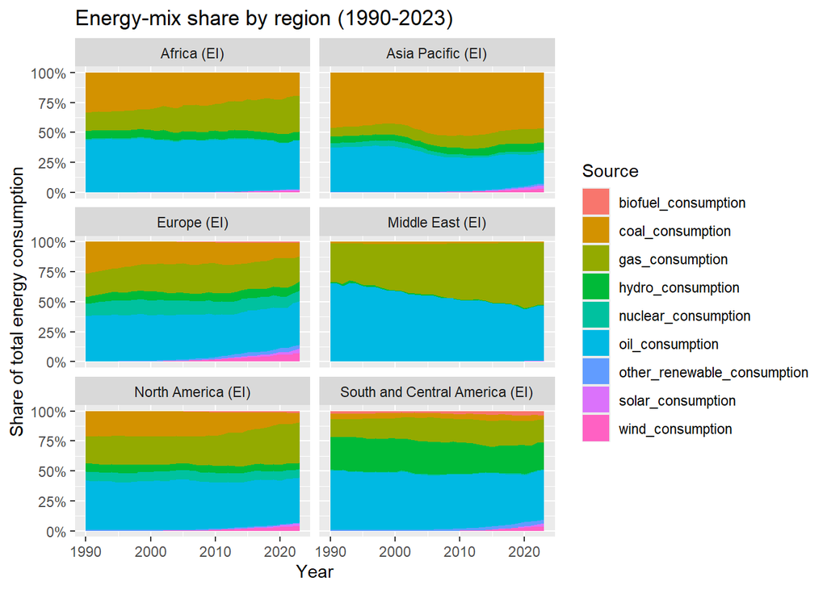

```r
# Regional energy-mix trends  (stacked area charts)

regions_vec <- c(
  "Africa (EI)", "Asia Pacific (EI)", "Europe (EI)",
  "Middle East (EI)", "North America (EI)", "South and Central America (EI)"
)

# Keep the six regions, years ≥ 1990
by_region <- energyData %>%                                   # master data-frame
  filter(country %in% regions_vec, year >= 1990)

# Columns that store individual sources (same set as in task 2.a)
src_cols <- colnames(sources)[-1]

# Compute total + reshape to long + relative share
long_reg <- by_region %>%
  mutate(total = rowSums(select(., all_of(src_cols)), na.rm = TRUE)) %>%
  melt(id.vars = c("country", "year", "total"),
       measure.vars = src_cols,
       variable.name = "source",
       value.name    = "value") %>%
  filter(!is.na(value), total > 0) %>%                       # avoid division by zero
  mutate(share = value / total)

# Stacked area chart with facets (one facet per region)
ggplot(long_reg, aes(year, share, fill = source)) +
  geom_area(position = "stack") +
  facet_wrap(~ country, ncol = 2) +
  scale_y_continuous(labels = scales::percent_format()) +     # % axis
  labs(
    title = "Energy-mix share by region (1990-2023)",
    y     = "Share of total energy consumption",
    x     = "Year",
    fill  = "Source"
  )
```

Each subplot shows the energy mix by year for one region, using different colors for different energy sources. The x-axis shows the years from 1990 to 2023, and the y-axis shows the relative share (%) of each source.

#### 5.2 A 2020 map trilogy: nuclear share, energy use per person, and gas demand

Turning from regions to individual countries, we paint three choropleth maps for 2020.

```r
# Prepare 2020 data, keep only actual countries (no “(EI)” aggregates)
data2020 <- energyData %>%
  filter(year == 2020, !str_detect(country, "\\(EI\\)")) %>%
  select(country, iso_code, nuclear_share_elec, energy_per_capita, gas_consumption)

# Helper to join and plot a world map for a given column
plot_map <- function(df, col, title) {
  map_df <- joinCountryData2Map(
    df,
    joinCode       = "ISO3",
    nameJoinColumn = "iso_code",
    verbose        = FALSE
  )
  mapCountryData(
    map_df,
    nameColumnToPlot = col,
    mapTitle         = title,
    catMethod        = "pretty",
    colourPalette = RColorBrewer::brewer.pal(7, "Blues"),
    addLegend        = TRUE
  )
}
```

**Nuclear share in electricity**

```
## 215 codes from your data successfully matched countries in the map
## 43 codes from your data failed to match with a country code in the map
## 28 codes from the map weren't represented in your data
```

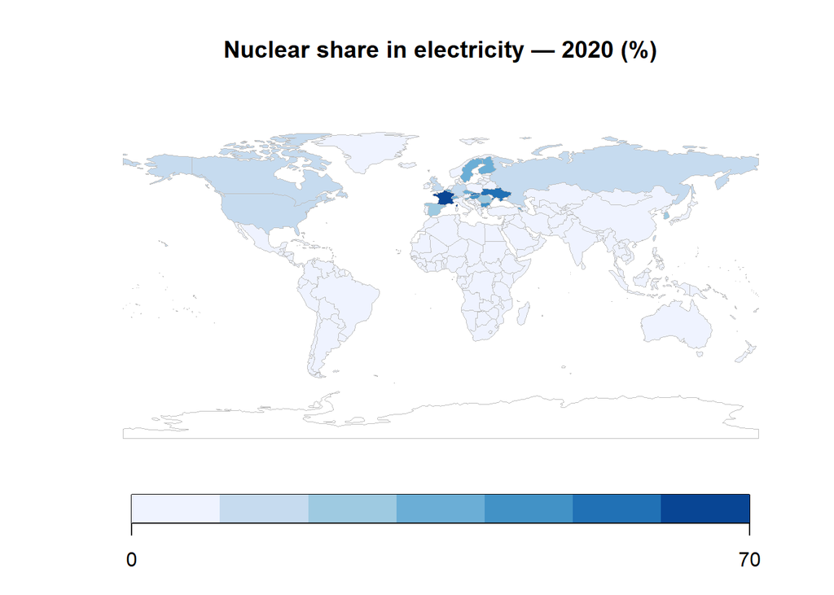

```r
# Nuclear share in electricity (2020)
plot_map(
  data2020,
  "nuclear_share_elec",
  "Nuclear share in electricity — 2020 (%)"
)
```

**Energy use per capita**

```
## 215 codes from your data successfully matched countries in the map
## 43 codes from your data failed to match with a country code in the map
## 28 codes from the map weren't represented in your data
```

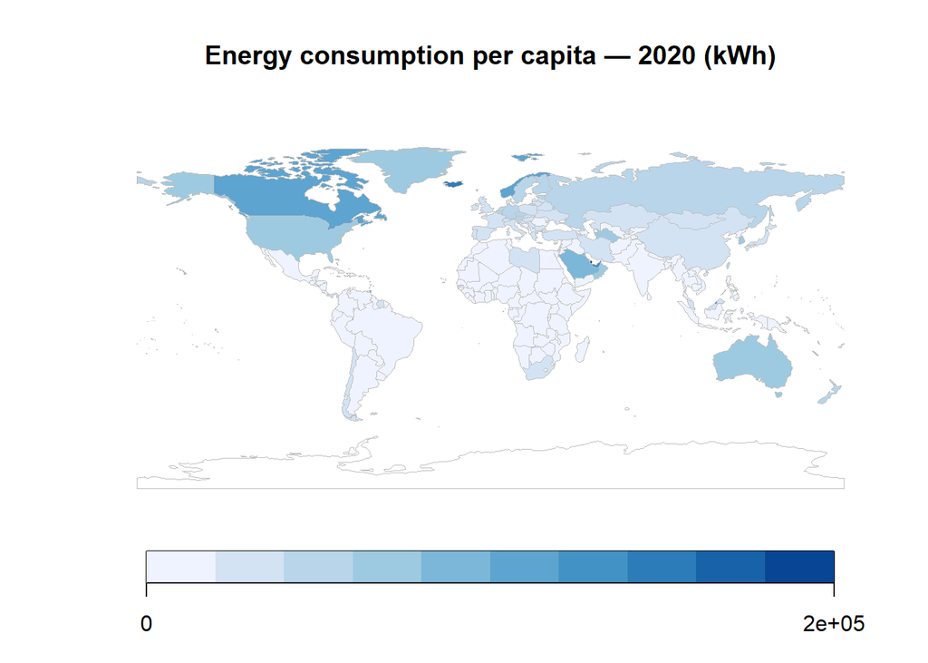

```r
# Energy consumption per capita (2020)
plot_map(
  data2020,
  "energy_per_capita",
  "Energy consumption per capita — 2020 (kWh)"
)
```

Per-capita energy use in 2020 peaks in northern and desert environments. Iceland, Norway, Canada and the United States dominate the high latitudes, where heating needs and energy-intensive industries lift consumption, whereas Qatar, Kuwait and the United Arab Emirates stand out on the Arabian Peninsula as hydrocarbon-rich states whose small populations drive the statistic upward. In stark contrast, a wide belt covering sub-Saharan Africa and South Asia displays the lowest personal energy footprints.

**Total gas consumption**

```
## 215 codes from your data successfully matched countries in the map
## 43 codes from your data failed to match with a country code in the map
## 28 codes from the map weren't represented in your data
```

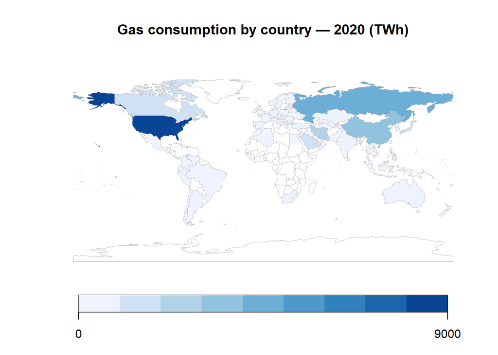

```r
# Gas consumption (2020)
plot_map(
  data2020,
  "gas_consumption",
  "Gas consumption by country — 2020 (TWh)"
)
```

Global gas consumption reveals two broad demand corridors. One links the United States and Canada in North America, shaped by long-standing pipeline integration and the recent shale boom. The other runs from Western Europe and Russia across Kazakhstan and Uzbekistan into China, following both resource endowments and transcontinental infrastructure. A separate hotspot in the Middle East, centered on Iran and Saudi Arabia, underscores the region’s role as both a producer and an increasingly large domestic consumer of natural gas.

Together these three maps show how geography, climate and resource endowment shape today’s energy landscape and underscore the uneven pace of the global transition.

### Part 6: Can crises be spotted in the energy record?

#### 6.1 Global shocks in primary energy demand

We want to detect major global shocks by tracking year-over-year shifts in total primary energy consumption. To do that, we’ll filter for the “World” aggregate since 1985, compute the annual percentage change in primary_energy_consumption, and then plot those changes over time.

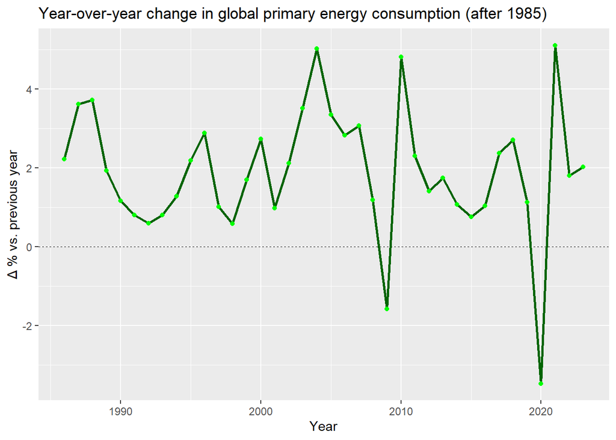

```r
worldTrend <- energyData %>%
  filter(country == "World", year > 1984) %>%
  arrange(year)

  worldTrend$yoy_change <- NA


  for (i in 2:nrow(worldTrend)) {
  prev <- worldTrend$primary_energy_consumption[i - 1]  # previous year
  curr <- worldTrend$primary_energy_consumption[i]      # current year

  worldTrend$yoy_change[i] <- 100 * (curr - prev) / prev}

  # Remove the first row (it has NA because there is no previous year)
  worldTrend <- worldTrend %>% drop_na(yoy_change)


  ggplot(worldTrend, aes(year, yoy_change)) +
  geom_hline(yintercept = 0, linetype = "dashed", linewidth = 0.3) +
  geom_line(color = "darkgreen", linewidth = 1) +
  geom_point(color = "green", size = 1.5) +
  labs(
    title = "Year-over-year change in global primary energy consumption (after 1985)",
    x     = "Year",
    y     = "Δ % vs. previous year"
  )
```

#### 6.2 The steepest nuclear drop-offs on record

To see which national nuclear programmes suffered the worst single-country collapses, we calculate annual percentage changes in **nuclear consumption** for every country, smooth them with a three-year moving average, and rank five the most negative episodes.

```r
  calc_nuclear_change_loop <- function(df, country_name) {
  # Keep one country and sort by year
  one <- df %>%
    filter(country == country_name) %>%
    arrange(year) %>%
    select(country, year, nuclear_consumption)

  n <- nrow(one)

  #Add empty columns for results
  one$yoy <- NA        # year-over-year %
  one$ma3 <- NA        # 3-year moving average of YoY

  #Loop to compute YoY from the 2nd row onward
  for (i in 2:n) {
    prev <- one$nuclear_consumption[i - 1]
    curr <- one$nuclear_consumption[i]
    if (!is.na(prev) && prev != 0) {
      one$yoy[i] <- 100 * (curr - prev) / prev
      }
    }

  #3-year moving average of YoY via rollmean
  one$ma3 <- stats::filter(
  one$yoy,
  rep(1/3, 3),
  sides = 1
)
return(one)}

  country_list <- unique(energyData$country)   # country list
all_results  <- data.frame()                     # empty tibble

for (cn in country_list) {
  tmp <- calc_nuclear_change_loop(energyData, cn)  # for one counrty calculate
  all_results <- bind_rows(all_results, tmp)       # add rows to the bottom
}

top5_drops <- all_results %>%
  filter(!is.na(ma3)) %>%                   # MA must be defined
  arrange(ma3) %>%                          # ascending → most negative first
  slice_head(n = 5)

# Round the two numeric columns to 2 decimal places
top5_drops$yoy <- round(top5_drops$yoy, 2)
top5_drops$ma3 <- round(top5_drops$ma3, 2)

# Print the table to the console
print(top5_drops)
```

```
##    country year nuclear_consumption     yoy    ma3
## 1    Japan 2014               0.000 -100.00 -69.45
## 2    Italy 1988               0.000 -100.00 -57.78
## 3 Pakistan 1979               0.150  -68.55 -51.30
## 4    Japan 2013              38.191  -19.32 -50.99
## 5   Brazil 1994               0.156  -87.56 -46.82
```

Each case aligns with a well-documented political, technical or safety crisis. Japan’s 2013 drop shows the start of its post-Fukushima shutdown process. Japan’s biggest drop in 2014 comes from shutting down all reactors after the 2011 Fukushima accident. Italy’s steep fall in 1988 happened after the Chernobyl disaster when the country voted to end nuclear power. Pakistan in 1979 and Brazil in 1994 both saw their nuclear numbers fall to almost zero, likely due to policy changes or gaps in data.

#### 6.3 Japan’s post-Fukushima collapse in context

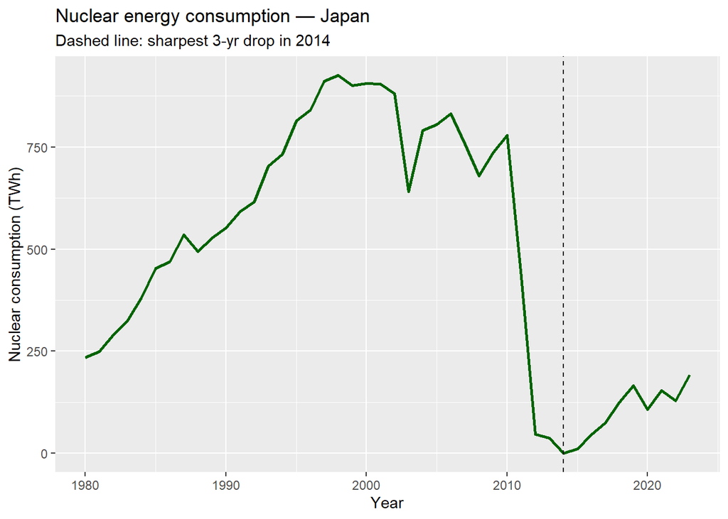

```r
# Pick the country–year with the worst 3-year drop
top_pair    <- top5_drops[1, ]
top_country <- top_pair$country
top_year    <- top_pair$year

# Nuclear consumption for that country since 1980
country_nuc <- energyData %>%
  filter(country == top_country, year >= 1980) %>%
  arrange(year)

# Plot and mark the changepoint
ggplot(country_nuc, aes(year, nuclear_consumption)) +
  geom_line(color = "darkgreen", linewidth = 1) +
  geom_vline(xintercept = top_year, linetype = "dashed", color = "black") +
  labs(
    title    = paste("Nuclear energy consumption —", top_country),
    subtitle = paste("Dashed line: sharpest 3-yr drop in", top_year),
    x = "Year",
    y = "Nuclear consumption (TWh)"
  )
```

This episode demonstrates how a single catastrophic event can erase decades of steady growth and highlights the sensitivity of national energy systems to sudden shocks—information that is critical for both risk assessment and long-term planning.